# Praktikum 3 Regresi dengan Peubah Lag

## Impor Data

```r
datasales <- rio::import("https://raw.githubusercontent.com/aidara11/mpdw/main/Pertemuan%203/salesmonthly.csv")
str(datasales)
```

```
## 'data.frame':    70 obs. of  9 variables:
##  $ datum: IDate, format: "2014-01-31" "2014-02-28" ...
##  $ M01AB: num  128 133 137 113 102 ...
##  $ M01AE: num  99.1 126.1 93 89.5 119.9 ...
##  $ N02BA: num  152 177 148 131 132 ...
##  $ N02BE: num  878 1002 779 698 629 ...
##  $ N05B : num  354 347 232 209 270 323 348 420 399 472 ...
##  $ N05C : num  50 31 20 18 23 23 21 29 14 30 ...
##  $ R03  : num  112 122 112 97 107 57 61 37 115 182 ...
##  $ R06  : num  48.2 36.2 85.4 73.7 123.7 ...
```

```r
datasales
```

```
##         datum  M01AB   M01AE   N02BA    N02BE  N05B N05C    R03    R06
## 1  2014-01-31 127.69  99.090 152.100  878.030 354.0   50 112.00  48.20
## 2  2014-02-28 133.32 126.050 177.000 1001.900 347.0   31 122.00  36.20
## 3  2014-03-31 137.44  92.950 147.655  779.275 232.0   20 112.00  85.40
## 4  2014-04-30 113.10  89.475 130.900  698.500 209.0   18  97.00  73.70
## 5  2014-05-31 101.79 119.933 132.100  628.780 270.0   23 107.00 123.70
## 6  2014-06-30 112.07  94.710 122.900  548.225 323.0   23  57.00 109.30
## 7  2014-07-31 117.06  95.010 129.300  491.900 348.0   21  61.00  69.10
## 8  2014-08-31 134.79  99.780 123.800  583.850 420.0   29  37.00  70.80
## 9  2014-09-30 108.78 109.094 122.100  887.820 399.0   14 115.00  58.80
## 10 2014-10-31 154.75 185.241 191.600 1856.815 472.0   30 182.00  74.50
## 11 2014-11-30 138.08 100.860 142.700  723.800 489.0   19 112.00  45.20
## 12 2014-12-31 131.90 121.401 111.124 1015.660 492.0   25 163.00  33.40
## 13 2015-01-31 135.91 130.349 141.000 1044.240 463.0   24 177.25  42.00
## 14 2015-02-28 115.71 123.740 131.830  953.252 243.0    9 208.00  47.00
```

[output cut: 56 more lines]

### Pembagian Data

```r
#SPLIT DATA
train <- datasales [1:56,]
train
```

```
##         datum  M01AB   M01AE   N02BA    N02BE  N05B N05C    R03    R06
## 1  2014-01-31 127.69  99.090 152.100  878.030 354.0   50 112.00  48.20
## 2  2014-02-28 133.32 126.050 177.000 1001.900 347.0   31 122.00  36.20
## 3  2014-03-31 137.44  92.950 147.655  779.275 232.0   20 112.00  85.40
## 4  2014-04-30 113.10  89.475 130.900  698.500 209.0   18  97.00  73.70
## 5  2014-05-31 101.79 119.933 132.100  628.780 270.0   23 107.00 123.70
## 6  2014-06-30 112.07  94.710 122.900  548.225 323.0   23  57.00 109.30
## 7  2014-07-31 117.06  95.010 129.300  491.900 348.0   21  61.00  69.10
## 8  2014-08-31 134.79  99.780 123.800  583.850 420.0   29  37.00  70.80
## 9  2014-09-30 108.78 109.094 122.100  887.820 399.0   14 115.00  58.80
## 10 2014-10-31 154.75 185.241 191.600 1856.815 472.0   30 182.00  74.50
## 11 2014-11-30 138.08 100.860 142.700  723.800 489.0   19 112.00  45.20
## 12 2014-12-31 131.90 121.401 111.124 1015.660 492.0   25 163.00  33.40
## 13 2015-01-31 135.91 130.349 141.000 1044.240 463.0   24 177.25  42.00
## 14 2015-02-28 115.71 123.740 131.830  953.252 243.0    9 208.00  47.00
```

[output cut: 42 more lines]

```r
test  <- datasales [57:70,]
test
```

```
##         datum  M01AB   M01AE  N02BA    N02BE  N05B N05C R03    R06
## 57 2018-09-30 153.52 114.992  86.50 1058.262 263.0   12 205  88.10
## 58 2018-10-31 144.71 129.400  76.05 1129.275 287.0   25 353  76.90
## 59 2018-11-30 172.29 105.487 102.15  995.150 252.2   22 311  48.40
## 60 2018-12-31 147.71 113.024  84.75 1213.950 254.0   27 384  53.10
## 61 2019-01-31 179.70 222.351  99.70 1660.612 295.2   23 386  41.30
## 62 2019-02-28 133.73 142.155 110.20 1001.212 249.4   12 226  69.50
## 63 2019-03-31 154.52 113.118  83.35  941.050 301.4   19 257 169.50
## 64 2019-04-30 161.39 100.165  88.10  647.650 299.4   22 259 179.10
## 65 2019-05-31 168.04  97.258 104.10  703.562 265.8   26 322 135.40
## 66 2019-06-30 151.54 101.627 103.20  610.000 193.0   25 142 156.04
## 67 2019-07-31 181.00 103.541  92.80  649.800 250.6   20 115 105.20
## 68 2019-08-31 181.91  88.269  84.20  518.100 237.0   26 145  97.30
## 69 2019-09-30 161.07 111.437  93.50  984.480 227.8   16 161 109.10
## 70 2019-10-31  44.37  37.300  20.65  295.150  86.0    7  37  11.13
```

### Mengubah format data jadi time series

```r
train.ts <- ts(train)
test.ts  <- ts(test)
data.ts  <- ts(datasales)
```

## Model Koyck

Model Koyck didasarkan pada asumsi bahwa semakin jauh jarak lag peubah independen (x) dari periode sekarang maka semakin kecil pengaruh peubah lag terhadap peubah dependen (y).

Koyck mengusulkan suatu metode untuk menduga model dinamis distributed lag dengan mengasumsikan bahwa semua koefisien $\beta$ mempunyai tanda sama.

Model kyock merupakan jenis paling umum dari model infinite distributed lag dan juga dikenal sebagai geometric lag

$$y_t=a(1-\lambda)+\beta_0X_t+\beta_1Z_t+\lambda Y_{t-1}+V_t$$

dengan
$$V_t=u_t-\lambda
u_{t-1}$$

### Pemodelan

Pemodelan model Koyck dengan `R` dapat menggunakan `dLagM::koyckDlm()` .

Fungsi `koyckDlm()` akan menerapkan model lag terdistribusi dengan transformasi Koyck satu prediktor. Nilai `x` dan `y` tidak perlu sebagai objek *time series* (`ts`). `intercept` dapat dibuat `TRUE` untuk memasukkan intersep ke dalam model.

```r
#MODEL KOYCK
model.koyck <- koyckDlm(x = train$R03, y = train$N05B)
summary(model.koyck)
```

```
##
## Call:
## "Y ~ (Intercept) + Y.1 + X.t"
##
## Residuals:
##     Min      1Q  Median      3Q     Max
## -366.77  -31.68   -4.25   46.64  201.12
##
## Coefficients:
##             Estimate Std. Error t value Pr(>|t|)
## (Intercept) 176.2521    68.7616   2.563   0.0133 *
## Y.1           0.7452     0.1222   6.098 1.35e-07 ***
## X.t          -0.7289     0.4028  -1.809   0.0762 .
## ---
## Signif. codes:  0 '***' 0.001 '**' 0.01 '*' 0.05 '.' 0.1 ' ' 1
##
## Residual standard error: 82.42 on 52 degrees of freedom
## Multiple R-Squared: 0.2113,  Adjusted R-squared: 0.181
## Wald test: 19.79 on 2 and 52 DF,  p-value: 4.056e-07
##
## Diagnostic tests:
## NULL
##
##                           alpha       beta       phi
## Geometric coefficients:  691.77 -0.7289469 0.7452158
```

```r
AIC(model.koyck)
```

```
## [1] 646.2944
```

```r
BIC(model.koyck)
```

```
## [1] 654.3238
```

Dari hasil tersebut, didapat bahwa peubah `x_t` memiliki nilai `P-Value > 0.05` dan `y_{t-1}` memiliki nilai `P-Value<0.05`. Hal ini menunjukkan bahwa peubah `x_t` tidak berpengaruh signifikan pada taraf nyata 5% (namun berpengaruh signifikan pada taraf nyata 10%) dan peubah `y_{t-1}` berpengaruh signifikan terhadap `y` pada taraf nyata 5%. Adapun model keseluruhannya adalah sebagai berikut

### Peramalan dan Akurasi

Berikut adalah hasil peramalan y untuk 14 periode kedepan menggunakan model koyck

```r
fore.koyck <- forecast(model = model.koyck, x = test$R03, h=14)  #h = periode peramalan
fore.koyck
```

```
## $forecasts
##  [1]  215.357534   79.421627    8.735812  -97.153501 -177.521784 -120.781988
##  [7] -101.095951  -87.883499 -123.961028  -19.636124   77.790010  128.525097
## [13]  154.670535  264.543948
##
## $call
## forecast.koyckDlm(model = model.koyck, x = test$R03, h = 14)
##
## attr(,"class")
## [1] "forecast.koyckDlm" "dLagM"
```

```r
mape.koyck <- MAPE(fore.koyck$forecasts, test$N05B)

#akurasi data training
GoF(model.koyck)
```

```
##              n      MAE       MPE    MAPE     sMAPE     MASE      MSE     MRAE
## model.koyck 55 53.96828 -6.666903 6.85131 0.2241851 1.215806 6421.947 3.419882
##                GMRAE
## model.koyck 1.186783
```

Pada perhitungan keakuratan model menggunakan metode Koyck didapatkan nilai MAPE 6,85%. Nilai akurasi model ini kurang dari 10% sehingga dapat dikategorikan sangat baik.

## Regression with Distributed Lag

Pemodelan model Regression with Distributed Lag dengan `R` dapat menggunakan `dLagM::dlm()` .

Fungsi `dlm()` akan menerapkan model lag terdistribusi dengan satu atau lebih prediktor. Nilai `x` dan `y` tidak perlu sebagai objek *time series* (`ts`). $q$ adalah integer yang mewakili panjang *lag* yang terbatas.

### Pemodelan (Lag=2)

```r
model.dlm <- dlm(x = train$R03 ,y = train$N05B , q = 2)
summary(model.dlm)
```

```
##
## Call:
## lm(formula = model.formula, data = design)
##
## Residuals:
##     Min      1Q  Median      3Q     Max
## -183.62  -46.80  -15.87   35.00  241.15
##
## Coefficients:
##             Estimate Std. Error t value Pr(>|t|)
## (Intercept) 284.5485    39.8756   7.136 3.68e-09 ***
## x.t           0.2829     0.2115   1.337    0.187
## x.1          -0.2855     0.2258  -1.264    0.212
## x.2          -0.1429     0.2131  -0.670    0.506
## ---
## Signif. codes:  0 '***' 0.001 '**' 0.01 '*' 0.05 '.' 0.1 ' ' 1
##
## Residual standard error: 90.77 on 50 degrees of freedom
## Multiple R-squared:  0.06547,    Adjusted R-squared:  0.0094
## F-statistic: 1.168 on 3 and 50 DF,  p-value: 0.3314
##
## AIC and BIC values for the model:
##        AIC      BIC
## 1 645.9927 655.9377
```

```r
AIC(model.dlm)
```

```
## [1] 645.9927
```

```r
BIC(model.dlm)
```

```
## [1] 655.9377
```

Dari hasil diatas, didapat bahwa $P-value$ dari intercept < 0.05. Hal ini menunjukkan bahwa intercept berpengaruh signifikan terhadap $y$. Adapun model keseluruhan yang terbentuk adalah sebagai berikut

$$\hat{Y_t}=284.5485+0.2829X_t-0.2855X_{t-1}-0.1429X_{t-2}$$

### Peramalan dan Akurasi

Berikut merupakan hasil peramalan $y$ untuk 14 periode kedepan

```r
fore.dlm <- forecast(model = model.dlm, x=test$R03, h=14)
fore.dlm
```

```
## $forecasts
##  [1] 284.2924 303.1688 242.4675 253.9589 239.6881 183.4244 237.5805 252.1602
##  [9] 264.9814 195.7928 230.5342 272.4488 272.2695 228.3377
##
## $call
## forecast.dlm(model = model.dlm, x = test$R03, h = 14)
##
## attr(,"class")
## [1] "forecast.dlm" "dLagM"
```

```r
mape.dlm <- MAPE(fore.dlm$forecasts, test$N05B)

#akurasi data training
GoF(model.dlm)
```

```
##            n      MAE      MPE     MAPE     sMAPE     MASE      MSE     MRAE
## model.dlm 54 65.42553 -3.47443 3.642495 0.2626092 1.519524 7629.412 4.846577
##              GMRAE
## model.dlm 1.517162
```

Pada perhitungan keakuratan model menggunakan metode Regression with Distributed Lag didapatkan nilai MAPE 3.64%. Nilai akurasi model ini kurang dari 10% sehingga dapat dikategorikan sangat baik.

### *Lag* Optimum

```r
#penentuan lag optimum
finiteDLMauto(formula = N05B ~ R06,
              data = data.frame(train), q.min = 1, q.max = 6,
              model.type = "dlm", error.type = "AIC", trace = FALSE)
```

```
##   q - k    MASE      AIC      BIC   GMRAE   MBRAE R.Adj.Sq    Ljung-Box
## 6     6 1.51882 611.0544 628.2627 1.47196 1.37676 -0.11642 4.593417e-08
```

```r
#model dlm dengan lag optimum
model.dlm2 <- dlm(x = train$R03,y = train$N05B, q = 6) # q = lag
summary(model.dlm2)
```

```
##
## Call:
## lm(formula = model.formula, data = design)
##
## Residuals:
##     Min      1Q  Median      3Q     Max
## -188.75  -60.24  -10.03   58.38  204.51
##
## Coefficients:
##               Estimate Std. Error t value Pr(>|t|)
## (Intercept)  3.472e+02  6.088e+01   5.703 1.06e-06 ***
## x.t          2.781e-01  2.344e-01   1.187    0.242
## x.1         -3.311e-01  2.503e-01  -1.323    0.193
## x.2         -9.296e-04  2.513e-01  -0.004    0.997
## x.3         -7.038e-02  2.518e-01  -0.279    0.781
## x.4         -2.758e-01  2.539e-01  -1.086    0.283
## x.5         -5.309e-02  2.543e-01  -0.209    0.836
## x.6         -1.032e-01  2.417e-01  -0.427    0.672
## ---
## Signif. codes:  0 '***' 0.001 '**' 0.01 '*' 0.05 '.' 0.1 ' ' 1
##
## Residual standard error: 94.47 on 42 degrees of freedom
## Multiple R-squared:  0.1349, Adjusted R-squared:  -0.009237
## F-statistic: 0.9359 on 7 and 42 DF,  p-value: 0.4894
##
## AIC and BIC values for the model:
##        AIC      BIC
## 1 606.0077 623.2159
```

```r
AIC(model.dlm2)
```

```
## [1] 606.0077
```

```r
BIC(model.dlm2)
```

```
## [1] 623.2159
```

Dari hasil tersebut tidak terdapat peubah yang berpengaruh signifikan terhadap taraf nyata 5%. Adapun keseluruhan model yang terbentuk adalah

$$\hat{Y_t}=347.2+0.2781X_t+...-0.1032X_{t-6}$$

Adapun hasil peramalan 14 periode kedepan menggunakan model tersebut adalah sebagai berikut

```r
#peramalan dan akurasi
fore.dlm2 <- forecast(model = model.dlm2, x=test$R03, h=14)
mape.dlm2<- MAPE(fore.dlm2$forecasts, test$N05B)

#akurasi data training
GoF(model.dlm2)
```

```
##             n      MAE       MPE     MAPE     sMAPE     MASE      MSE     MRAE
## model.dlm2 50 70.35149 -3.847603 4.039386 0.2859447 1.626049 7497.145 4.920313
##               GMRAE
## model.dlm2 1.900647
```

Didapatkan nilai MAPE sebesar 4.03%. Model tersebut merupakan model yang sangat baik dengan nilai MAPE yang kurang dari 10%.

## Model Autoregressive

Peubah dependen (y) dipengaruhi oleh peubah independen (x) pada waktu sekarang, serta dipengaruhi juga oleh peubah dependen (y) itu sendiri pada satu waktu yang lalu maka model tersebut disebut *autoregressive* (Gujarati 2004).

### Pemodelan

Pemodelan Autoregressive dilakukan menggunakan fungsi `dLagM::ardlDlm()` . Fungsi tersebut akan menerapkan *autoregressive* berordo $(p,q)$ dengan satu prediktor. Fungsi umum dari `ardlDlm()` adalah sebagai berikut.

```r
ardlDlm(formula = NULL , data = NULL , x = NULL , y = NULL , p = 1 , q = 1 ,
         remove = NULL )
```

Dengan $p$ adalah integer yang mewakili panjang *lag* yang terbatas dan $q$ adalah integer yang merepresentasikan ordo dari proses *autoregressive*.

```r
model.ardl <- ardlDlm(x = train$R03, y = train$N05B, p = 1 , q = 1)
summary(model.ardl)
```

```
##
## Time series regression with "ts" data:
## Start = 2, End = 56
##
## Call:
## dynlm(formula = as.formula(model.text), data = data, start = 1)
##
## Residuals:
##     Min      1Q  Median      3Q     Max
## -173.74  -26.44    5.52   28.66  126.83
##
## Coefficients:
##             Estimate Std. Error t value Pr(>|t|)
## (Intercept) 86.65801   31.05817   2.790  0.00739 **
## X.t          0.27744    0.13164   2.108  0.04000 *
## X.1         -0.43069    0.13151  -3.275  0.00190 **
## Y.1          0.75316    0.08437   8.927 5.33e-12 ***
## ---
## Signif. codes:  0 '***' 0.001 '**' 0.01 '*' 0.05 '.' 0.1 ' ' 1
##
## Residual standard error: 56.81 on 51 degrees of freedom
## Multiple R-squared:  0.6325, Adjusted R-squared:  0.6109
## F-statistic: 29.26 on 3 and 51 DF,  p-value: 3.819e-11
```

```r
AIC(model.ardl)
```

```
## [1] 606.2956
```

```r
BIC(model.ardl)
```

```
## [1] 616.3323
```

Dari hasil tersebut, didapat bahwa peubah $x_t$ , $x_{t-1}$ , dan $y_{t-1}$ memiliki nilai `P-Value < 0.05` Hal ini menunjukkan bahwa ketiga peubah tersebut berpengaruh signifikan terhadap $y_t$ pada taraf nyata 5%. Model keseluruhannya adalah sebagai berikut:

### Peramalan dan Akurasi

```r
fore.ardl <- forecast(model = model.ardl, x=test$R03, h=14)
fore.ardl
```

```
## $forecasts
##  [1] 265.6047 296.3481 244.1082 243.1054 211.4646 142.3815 167.8618 174.2561
##  [9] 195.6897 134.7592 158.9018 197.0371 217.2776 191.2279
##
## $call
## forecast.ardlDlm(model = model.ardl, x = test$R03, h = 14)
##
## attr(,"class")
## [1] "forecast.ardlDlm" "dLagM"
```

Data di atas merupakan hasil peramalan untuk 14 periode ke depan menggunakan Model Autoregressive dengan $p=1$ dan $q=1$.

```r
mape.ardl <- MAPE(fore.ardl$forecasts, test$N05B)
mape.ardl
```

```
## [1] 0.2900784
```

```r
#akurasi data training
GoF(model.ardl)
```

```
##             n      MAE       MPE     MAPE     sMAPE      MASE      MSE     MRAE
## model.ardl 55 40.79747 -2.938051 3.068268 0.1763384 0.9190919 2992.491 1.818713
##                GMRAE
## model.ardl 0.9112162
```

### *Lag* Optimum

```r
#penentuan lag optimum
model.ardl.opt <- ardlBoundOrders(data = data.frame(datasales), ic = "AIC",
                                  formula = N05B ~ R03 )
min_p=c()
for(i in 1:6){
  min_p[i]=min(model.ardl.opt$Stat.table[[i]])
}
q_opt=which(min_p==min(min_p, na.rm = TRUE))
p_opt=which(model.ardl.opt$Stat.table[[q_opt]] ==
              min(model.ardl.opt$Stat.table[[q_opt]], na.rm = TRUE))
data.frame("q_optimum" = q_opt, "p_optimum" = p_opt,
           "AIC"=model.ardl.opt$min.Stat)
```

```
##   q_optimum p_optimum      AIC
## 1         5        15 556.9577
```

Dari tabel di atas, dapat terlihat bahwa nilai AIC terendah didapat ketika $p=15$ dan $q=5$, yaitu sebesar `556.9577`. Artinya, model autoregressive optimum didapat ketika $p=15$ dan $q=5$.

Selanjutnya dapat dilakukan pemodelan dengan nilai $p$ dan $q$ optimum seperti inisialisasi di langkah sebelumnya.

## Pemodelan DLM & ARDL dengan Library `dynlm`

Pemodelan regresi dengan peubah *lag* tidak hanya dapat dilakukan dengan fungsi pada *packages* `dLagM` , tetapi terdapat *packages* `dynlm` yang dapat digunakan. Fungsi `dynlm` secara umum adalah sebagai berikut.

```r
dynlm(formula, data, subset, weights, na.action, method = "qr",
  model = TRUE, x = FALSE, y = FALSE, qr = TRUE, singular.ok = TRUE,
  contrasts = NULL, offset, start = NULL, end = NULL, ...)
```

Untuk menentukan `formula` model yang akan digunakan, tersedia fungsi tambahan yang memungkinkan spesifikasi dinamika (melalui `d()` dan `L()`) atau pola linier/siklus dengan mudah (melalui `trend()`, `season()`, dan `harmon()`). Semua fungsi formula baru mengharuskan argumennya berupa objek deret waktu (yaitu, `"ts"` atau `"zoo"`).

```r
#sama dengan model dlm q=1
cons_lm1 <- dynlm(N05B ~ R03+L(R03),data = train.ts)
#sama dengan model ardl p=1 q=0
cons_lm2 <- dynlm(N05B ~ R03+L(N05B),data = train.ts)
#sama dengan ardl p=1 q=1
cons_lm3 <- dynlm(N05B ~ R03+L(R03)+L(N05B),data = train.ts)
#sama dengan dlm p=2
cons_lm4 <- dynlm(N05B ~ R03+L(R03)+L(R03,2),data = train.ts)
```

### Ringkasan Model

```r
summary(cons_lm1)
```

```
##
## Time series regression with "ts" data:
## Start = 2, End = 56
##
## Call:
## dynlm(formula = N05B ~ R03 + L(R03), data = train.ts)
##
## Residuals:
##     Min      1Q  Median      3Q     Max
## -179.61  -44.87  -17.64   38.90  246.21
##
## Coefficients:
##             Estimate Std. Error t value Pr(>|t|)
## (Intercept) 277.3904    35.7358   7.762 3.03e-10 ***
## R03           0.2630     0.2087   1.260   0.2132
## L(R03)       -0.3519     0.2080  -1.692   0.0967 .
## ---
## Signif. codes:  0 '***' 0.001 '**' 0.01 '*' 0.05 '.' 0.1 ' ' 1
##
## Residual standard error: 90.06 on 52 degrees of freedom
## Multiple R-squared:  0.0582, Adjusted R-squared:  0.02197
## F-statistic: 1.607 on 2 and 52 DF,  p-value: 0.2104
```

```r
summary(cons_lm2)
```

```
##
## Time series regression with "ts" data:
## Start = 2, End = 56
##
## Call:
## dynlm(formula = N05B ~ R03 + L(N05B), data = train.ts)
##
## Residuals:
##      Min       1Q   Median       3Q      Max
## -242.532  -24.849   -6.371   38.192  107.267
##
## Coefficients:
##             Estimate Std. Error t value Pr(>|t|)
## (Intercept) 54.73205   32.12801   1.704   0.0944 .
## R03          0.09277    0.12960   0.716   0.4773
## L(N05B)      0.73463    0.09171   8.010 1.23e-10 ***
## ---
## Signif. codes:  0 '***' 0.001 '**' 0.01 '*' 0.05 '.' 0.1 ' ' 1
##
## Residual standard error: 61.89 on 52 degrees of freedom
## Multiple R-squared:  0.5552, Adjusted R-squared:  0.5381
## F-statistic: 32.45 on 2 and 52 DF,  p-value: 7.121e-10
```

```r
summary(cons_lm3)
```

```
##
## Time series regression with "ts" data:
## Start = 2, End = 56
##
## Call:
## dynlm(formula = N05B ~ R03 + L(R03) + L(N05B), data = train.ts)
##
## Residuals:
##     Min      1Q  Median      3Q     Max
## -173.74  -26.44    5.52   28.66  126.83
##
## Coefficients:
##             Estimate Std. Error t value Pr(>|t|)
## (Intercept) 86.65801   31.05817   2.790  0.00739 **
## R03          0.27744    0.13164   2.108  0.04000 *
## L(R03)      -0.43069    0.13151  -3.275  0.00190 **
## L(N05B)      0.75316    0.08437   8.927 5.33e-12 ***
## ---
## Signif. codes:  0 '***' 0.001 '**' 0.01 '*' 0.05 '.' 0.1 ' ' 1
##
## Residual standard error: 56.81 on 51 degrees of freedom
## Multiple R-squared:  0.6325, Adjusted R-squared:  0.6109
## F-statistic: 29.26 on 3 and 51 DF,  p-value: 3.819e-11
```

```r
summary(cons_lm4)
```

```
##
## Time series regression with "ts" data:
## Start = 3, End = 56
##
## Call:
## dynlm(formula = N05B ~ R03 + L(R03) + L(R03, 2), data = train.ts)
##
## Residuals:
##     Min      1Q  Median      3Q     Max
## -183.62  -46.80  -15.87   35.00  241.15
##
## Coefficients:
##             Estimate Std. Error t value Pr(>|t|)
## (Intercept) 284.5485    39.8756   7.136 3.68e-09 ***
## R03           0.2829     0.2115   1.337    0.187
## L(R03)       -0.2855     0.2258  -1.264    0.212
## L(R03, 2)    -0.1429     0.2131  -0.670    0.506
## ---
## Signif. codes:  0 '***' 0.001 '**' 0.01 '*' 0.05 '.' 0.1 ' ' 1
##
## Residual standard error: 90.77 on 50 degrees of freedom
## Multiple R-squared:  0.06547,    Adjusted R-squared:  0.0094
## F-statistic: 1.168 on 3 and 50 DF,  p-value: 0.3314
```

## Perbandingan Model

```r
akurasi <- matrix(c(mape.koyck, mape.dlm, mape.dlm2, mape.ardl))
row.names(akurasi)<- c("Koyck","DLM 1","DLM 2","Autoregressive")
colnames(akurasi) <- c("MAPE")
akurasi
```

```
##                     MAPE
## Koyck          1.0770995
## DLM 1          0.2211184
## DLM 2          0.3067633
## Autoregressive 0.2900784
```

Berdasarkan nilai MAPE, model paling optimum didapat pada Model DLM 1 karena memiliki nilai MAPE yang terkecil.

### Plot

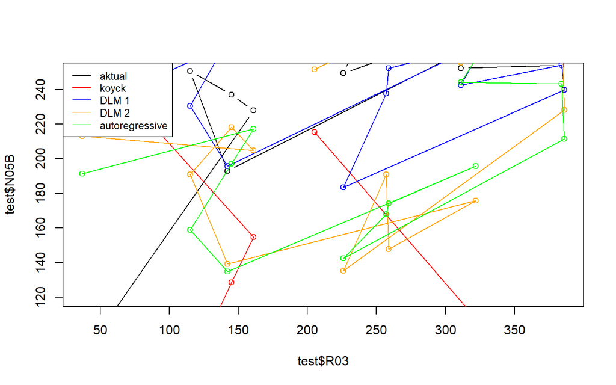

```r
par(mfrow=c(1,1))
plot(test$R03, test$N05B, type="b", col="black", ylim=c(120,250))
points(test$R03, fore.koyck$forecasts,col="red")
lines(test$R03, fore.koyck$forecasts,col="red")
points(test$R03, fore.dlm$forecasts,col="blue")
lines(test$R03, fore.dlm$forecasts,col="blue")
points(test$R03, fore.dlm2$forecasts,col="orange")
lines(test$R03, fore.dlm2$forecasts,col="orange")
points(test$R03, fore.ardl$forecasts,col="green")
lines(test$R03, fore.ardl$forecasts,col="green")
legend("topleft",c("aktual", "koyck","DLM 1","DLM 2", "autoregressive"), lty=1, col=c("black","red","blue","orange","green"), cex=0.8)
```

Berdasarkan plot tersebut, terlihat bahwa plot yang paling mendekati data aktualnya adalah Model DLM 1, sehingga dapat disimpulkan model terbaik dalam hal ini adalah model regresi DLM 1

## Pengayaan (Regresi Berganda)

### Data

```r
data(M1Germany)
data1 = M1Germany[1:144,]
```

### DLM

```r
#Run the search over finite DLMs according to AIC values
finiteDLMauto(formula = logprice ~ interest+logm1,
              data = data.frame(data1), q.min = 1, q.max = 5,
              model.type = "dlm", error.type = "AIC", trace = FALSE)
```

```
##   q - k    MASE       AIC       BIC   GMRAE    MBRAE R.Adj.Sq Ljung-Box
## 5     5 1.77163 -463.1393 -422.0566 1.43662 -1.60494  0.98836         0
```

```r
#model dlm berganda
model.dlmberganda = dlm(formula = logprice ~ interest + logm1,
                data = data.frame(data1) , q = 5)
summary(model.dlmberganda)
```

```
##
## Call:
## lm(formula = as.formula(model.formula), data = design)
##
## Residuals:
##       Min        1Q    Median        3Q       Max
## -0.095761 -0.028610 -0.000012  0.029496  0.102597
##
## Coefficients:
##             Estimate Std. Error t value Pr(>|t|)
## (Intercept) -7.81759    0.11384 -68.669  < 2e-16 ***
## interest.t  -1.75616    0.80358  -2.185 0.030707 *
## interest.1   1.38935    1.22707   1.132 0.259679
## interest.2   0.40776    1.23726   0.330 0.742273
## interest.3   1.23130    1.20752   1.020 0.309830
## interest.4  -0.08718    1.20869  -0.072 0.942616
## interest.5   3.06850    0.89380   3.433 0.000808 ***
## logm1.t      0.43219    0.20876   2.070 0.040474 *
## logm1.1      0.42190    0.19807   2.130 0.035109 *
## logm1.2      0.20943    0.12883   1.626 0.106532
## logm1.3      0.22053    0.13011   1.695 0.092567 .
## logm1.4      0.05513    0.21457   0.257 0.797633
## logm1.5      0.03042    0.19192   0.159 0.874296
## ---
## Signif. codes:  0 '***' 0.001 '**' 0.01 '*' 0.05 '.' 0.1 ' ' 1
##
## Residual standard error: 0.04343 on 126 degrees of freedom
## Multiple R-squared:  0.9894, Adjusted R-squared:  0.9884
## F-statistic: 977.9 on 12 and 126 DF,  p-value: < 2.2e-16
##
## AIC and BIC values for the model:
##         AIC       BIC
## 1 -463.1393 -422.0566
```

```r
model.dlmberganda2 = dlm(formula = logprice ~ interest + logm1,
                        data = data.frame(data1) , q = 1)
summary(model.dlmberganda2)
```

```
##
## Call:
## lm(formula = as.formula(model.formula), data = design)
##
## Residuals:
##       Min        1Q    Median        3Q       Max
## -0.134002 -0.044697  0.006407  0.036962  0.113063
##
## Coefficients:
##             Estimate Std. Error t value Pr(>|t|)
## (Intercept) -7.77917    0.13299 -58.492  < 2e-16 ***
## interest.t  -3.22103    0.94184  -3.420 0.000824 ***
## interest.1   6.52775    0.94501   6.908 1.66e-10 ***
## logm1.t      0.73918    0.08419   8.780 5.61e-15 ***
## logm1.1      0.63330    0.08429   7.513 6.55e-12 ***
## ---
## Signif. codes:  0 '***' 0.001 '**' 0.01 '*' 0.05 '.' 0.1 ' ' 1
##
## Residual standard error: 0.05443 on 138 degrees of freedom
## Multiple R-squared:  0.9832, Adjusted R-squared:  0.9828
## F-statistic:  2025 on 4 and 138 DF,  p-value: < 2.2e-16
##
## AIC and BIC values for the model:
##         AIC       BIC
## 1 -419.7575 -401.9805
```

### ARDL

```r
#Mencari orde lag optimum model ARDL
ardlBoundOrders(data = data1 , formula = logprice ~ interest + logm1,
                ic="AIC")
```

```
## $p
##    interest logm1
## 65        0     4
##
## $q
## [1] 4
##
## $Stat.table
##            q = 1     q = 2     q = 3     q = 4     q = 5     q = 6     q = 7
## p = 1  -760.1786 -757.9195 -846.8342 -975.2079 -965.7536 -958.9072 -956.7315
## p = 2  -760.0433 -759.3090 -843.6247 -971.2514 -961.7929 -955.2809 -953.4890
## p = 3  -753.7746 -753.7746 -841.2485 -970.4543 -961.4343 -953.7173 -950.0412
## p = 4  -829.8076 -832.6436 -832.6436 -971.0837 -962.1804 -955.0429 -953.4667
## p = 5  -749.4144 -753.2292 -962.9290 -962.9290 -961.7063 -954.3406 -951.7660
## p = 6  -742.2103 -742.9945 -891.6195 -952.3771 -952.3771 -952.2461 -950.1105
```

[output cut: 302 more lines]

```r
model.ardlDlmberganda = ardlDlm(formula = logprice ~ interest + logm1,
                        data = data.frame(data1) , p = 4 , q = 4)
summary(model.ardlDlmberganda)
```

```
##
## Time series regression with "ts" data:
## Start = 5, End = 144
##
## Call:
## dynlm(formula = as.formula(model.text), data = data)
##
## Residuals:
##        Min         1Q     Median         3Q        Max
## -0.0290527 -0.0075965  0.0005726  0.0072745  0.0304486
##
## Coefficients:
##               Estimate Std. Error t value Pr(>|t|)
## (Intercept)  0.0145022  0.1822785   0.080  0.93671
## interest.t   0.0067985  0.2135315   0.032  0.97465
## interest.1   0.6093502  0.3240545   1.880  0.06238 .
## interest.2   0.0798544  0.3221168   0.248  0.80461
## interest.3  -0.3638172  0.3238873  -1.123  0.26347
## interest.4   0.2084240  0.2447331   0.852  0.39604
## logm1.t      0.0828689  0.0457486   1.811  0.07248 .
## logm1.1     -0.0092841  0.0399079  -0.233  0.81642
## logm1.2     -0.1166129  0.0390732  -2.984  0.00342 **
## logm1.3      0.0007016  0.0389297   0.018  0.98565
## logm1.4      0.0447857  0.0425474   1.053  0.29455
## logprice.1   0.3274245  0.0651574   5.025  1.7e-06 ***
## logprice.2   0.1323801  0.0684485   1.934  0.05537 .
## logprice.3  -0.1448245  0.0674268  -2.148  0.03365 *
## logprice.4   0.6730871  0.0636443  10.576  < 2e-16 ***
## ---
## Signif. codes:  0 '***' 0.001 '**' 0.01 '*' 0.05 '.' 0.1 ' ' 1
##
## Residual standard error: 0.01132 on 125 degrees of freedom
## Multiple R-squared:  0.9993, Adjusted R-squared:  0.9992
## F-statistic: 1.273e+04 on 14 and 125 DF,  p-value: < 2.2e-16
```

```r
#model p interest 0 p logm1 4
rem.p = list(interest = c(1,2,3,4))
remove = list(p = rem.p)
model.ardlDlmberganda2 = ardlDlm(formula = logprice ~ interest + logm1,
                        data = data.frame(data1) , p = 4 , q = 4 ,
                        remove = remove)
summary(model.ardlDlmberganda2)
```

```
##
## Time series regression with "ts" data:
## Start = 5, End = 144
##
## Call:
## dynlm(formula = as.formula(model.text), data = data)
##
## Residuals:
##        Min         1Q     Median         3Q        Max
## -0.0290369 -0.0083445  0.0009024  0.0079199  0.0303652
##
## Coefficients:
##              Estimate Std. Error t value Pr(>|t|)
## (Intercept)  0.174838   0.133708   1.308  0.19333
## interest.t   0.448826   0.098736   4.546 1.24e-05 ***
## logm1.t      0.056659   0.043836   1.293  0.19849
## logm1.1     -0.017025   0.039159  -0.435  0.66446
## logm1.2     -0.118413   0.037399  -3.166  0.00193 **
## logm1.3     -0.006454   0.038112  -0.169  0.86580
## logm1.4      0.060220   0.040337   1.493  0.13789
## logprice.1   0.319059   0.062107   5.137 1.00e-06 ***
## logprice.2   0.111794   0.066101   1.691  0.09320 .
## logprice.3  -0.122129   0.065114  -1.876  0.06297 .
## logprice.4   0.699061   0.062611  11.165  < 2e-16 ***
## ---
## Signif. codes:  0 '***' 0.001 '**' 0.01 '*' 0.05 '.' 0.1 ' ' 1
##
## Residual standard error: 0.01149 on 129 degrees of freedom
## Multiple R-squared:  0.9993, Adjusted R-squared:  0.9992
## F-statistic: 1.73e+04 on 10 and 129 DF,  p-value: < 2.2e-16
```

Proses selanjutnya sama dengan pemodelan menggunakan peubah tunggal.